# Project: Investigate a Dataset - [No-show appointments in Brazil]

- Introduction
- Data Wrangling
- Exploratory Data Analysis
- Conclusions

## Introduction

This dataset collects information from 100k medical appointments in Brazil and is focused on the question of whether or not patients show up for their appointment. A number of characteristics about the patient are included in each row.

● ‘ScheduledDay’ tells us on what day the patient set up their appointment.

● ‘Neighborhood’ indicates the location of the hospital.

● ‘Scholarship’ indicateswhether or not the patient is enrolled in Brasilian welfare program Bolsa Família.

● Be careful about the encoding of the last column: it says ‘No’ if the patient showed up to their appointment, and ‘Yes’ if they did not show up.

### Dataset Description

noshowappointments-kagglev2-may-2016.csv

```python
# Use this cell to set up import statements for all of the packages that you
#   plan to use.

import numpy as np
import seaborn as sbn
import pandas as pd
from IPython.display import display

import matplotlib.pyplot as plt

# Remember to include a 'magic word' so that your visualizations are plotted
#   inline with the notebook. See this page for more:
#   http://ipython.readthedocs.io/en/stable/interactive/magics.html

%matplotlib inline
```

## Data Wrangling

In this section fo project: the wrangling of data via main three steps including

(1) gathering of data by loading the used files.

(2) the assesing of loaded data through functions for helping to understand ageneral veiw on the dataset.

(3) the cleaning process throth fixing and removing any non required data pirior to data analysis.

### (1) gathering data stage

```python
# loading files which will be used in dataset analysis.
# using head() function for showing the first five rows of data.
import pandas as pd
df= pd.read_csv('noshowappointments-kagglev2-may-2016.csv')
df.head()
```

|  | PatientId | AppointmentID | Gender | ScheduledDay | AppointmentDay | Age | Neighbourhood | Scholarship | Hipertension | Diabetes | Alcoholism | Handcap | SMS_received | No-show |
| --- | --- | --- | --- | --- | --- | --- | --- | --- | --- | --- | --- | --- | --- | --- |
| 0 | 2.987250e+13 | 5642903 | F | 2016-04-29T18:38:08Z | 2016-04-29T00:00:00Z | 62 | JARDIM DA PENHA | 0 | 1 | 0 | 0 | 0 | 0 | No |
| 1 | 5.589978e+14 | 5642503 | M | 2016-04-29T16:08:27Z | 2016-04-29T00:00:00Z | 56 | JARDIM DA PENHA | 0 | 0 | 0 | 0 | 0 | 0 | No |
| 2 | 4.262962e+12 | 5642549 | F | 2016-04-29T16:19:04Z | 2016-04-29T00:00:00Z | 62 | MATA DA PRAIA | 0 | 0 | 0 | 0 | 0 | 0 | No |
| 3 | 8.679512e+11 | 5642828 | F | 2016-04-29T17:29:31Z | 2016-04-29T00:00:00Z | 8 | PONTAL DE CAMBURI | 0 | 0 | 0 | 0 | 0 | 0 | No |
| 4 | 8.841186e+12 | 5642494 | F | 2016-04-29T16:07:23Z | 2016-04-29T00:00:00Z | 56 | JARDIM DA PENHA | 0 | 1 | 1 | 0 | 0 | 0 | No |

```python
# using tail() function for with fixed number (7) for showing the last seven rows of data.
df.tail(7)
```

|  | PatientId | AppointmentID | Gender | ScheduledDay | AppointmentDay | Age | Neighbourhood | Scholarship | Hipertension | Diabetes | Alcoholism | Handcap | SMS_received | No-show |
| --- | --- | --- | --- | --- | --- | --- | --- | --- | --- | --- | --- | --- | --- | --- |
| 110520 | 9.969977e+14 | 5650534 | F | 2016-05-03T07:51:47Z | 2016-06-07T00:00:00Z | 42 | MARIA ORTIZ | 0 | 0 | 0 | 0 | 0 | 1 | No |
| 110521 | 3.635534e+13 | 5651072 | F | 2016-05-03T08:23:40Z | 2016-06-07T00:00:00Z | 53 | MARIA ORTIZ | 0 | 0 | 0 | 0 | 0 | 1 | No |
| 110522 | 2.572134e+12 | 5651768 | F | 2016-05-03T09:15:35Z | 2016-06-07T00:00:00Z | 56 | MARIA ORTIZ | 0 | 0 | 0 | 0 | 0 | 1 | No |
| 110523 | 3.596266e+12 | 5650093 | F | 2016-05-03T07:27:33Z | 2016-06-07T00:00:00Z | 51 | MARIA ORTIZ | 0 | 0 | 0 | 0 | 0 | 1 | No |
| 110524 | 1.557663e+13 | 5630692 | F | 2016-04-27T16:03:52Z | 2016-06-07T00:00:00Z | 21 | MARIA ORTIZ | 0 | 0 | 0 | 0 | 0 | 1 | No |
| 110525 | 9.213493e+13 | 5630323 | F | 2016-04-27T15:09:23Z | 2016-06-07T00:00:00Z | 38 | MARIA ORTIZ | 0 | 0 | 0 | 0 | 0 | 1 | No |
| 110526 | 3.775115e+14 | 5629448 | F | 2016-04-27T13:30:56Z | 2016-06-07T00:00:00Z | 54 | MARIA ORTIZ | 0 | 0 | 0 | 0 | 0 | 1 | No |

### (2)-Assessing the data

-Assessing the loaded data through various functions for deeper understanding. -Obtaining general quick overview for the used data such as size , type , unique values, and statsticals information of data

```python
# using shape function to know the number of rows and coulmns
df.shape
```

```
(110527, 14)
```

this data consist of 110527 rows and 14 coulmns

```python
# using info function to obtain general overveiw of the data, and to check if any missing data .
df.info()
```

```
<class 'pandas.core.frame.DataFrame'>
RangeIndex: 110527 entries, 0 to 110526
Data columns (total 14 columns):
 #   Column          Non-Null Count   Dtype
---  ------          --------------   -----
 0   PatientId       110527 non-null  float64
 1   AppointmentID   110527 non-null  int64
 2   Gender          110527 non-null  object
 3   ScheduledDay    110527 non-null  object
 4   AppointmentDay  110527 non-null  object
 5   Age             110527 non-null  int64
 6   Neighbourhood   110527 non-null  object
 7   Scholarship     110527 non-null  int64
 8   Hipertension    110527 non-null  int64
 9   Diabetes        110527 non-null  int64
 10  Alcoholism      110527 non-null  int64
 11  Handcap         110527 non-null  int64
 12  SMS_received    110527 non-null  int64
 13  No-show         110527 non-null  object
dtypes: float64(1), int64(8), object(5)
memory usage: 11.8+ MB
```

1-this indicate that no missing data in this file as the number of entries are equal to the number of non null values in each coulmn. 2-there are a few incorect data types such as schedual day and appointment day show object type which may need to coverted to date time type in the cleaning process. 3- incorrect spelling of Hypertension which recorded incorrectly as Hipertension, this will be corrected in data cleaning stage.

```python
# using isnull() function for insuring that no missing data.
df.isnull().sum()
```

```
PatientId         0
AppointmentID     0
Gender            0
ScheduledDay      0
AppointmentDay    0
Age               0
Neighbourhood     0
Scholarship       0
Hipertension      0
Diabetes          0
Alcoholism        0
Handcap           0
SMS_received      0
No-show           0
dtype: int64
```

this isnull() function for duople checking and insuring that no null records(no missing data).

```python
 # using duplicated() function for calculating the number of identical duplicated rows if any.
sum (df.duplicated())
```

```
0
```

this result no duplicated rows in the data set

```python
#using duplicated functiin of patient id column to check if there are repeated records for same patient or no
df['PatientId'].duplicated().sum()
```

```
48228
```

48228 patient IDs have duplicated values so further investigations requred to check if these duplicated patients have same results or not.

```python
# using duplicated function for multi-columns for obtaining the number of patients who show the same status of showing .
df.duplicated(['PatientId','No-show']).sum()
```

```
38710
```

```python
# using describe() function for obtaining a general statistics such as min,max,standered deviation and mean of each column.
df.describe()
```

|  | PatientId | AppointmentID | Age | Scholarship | Hipertension | Diabetes | Alcoholism | Handcap | SMS_received |
| --- | --- | --- | --- | --- | --- | --- | --- | --- | --- |
| count | 1.105270e+05 | 1.105270e+05 | 110527.000000 | 110527.000000 | 110527.000000 | 110527.000000 | 110527.000000 | 110527.000000 | 110527.000000 |
| mean | 1.474963e+14 | 5.675305e+06 | 37.088874 | 0.098266 | 0.197246 | 0.071865 | 0.030400 | 0.022248 | 0.321026 |
| std | 2.560949e+14 | 7.129575e+04 | 23.110205 | 0.297675 | 0.397921 | 0.258265 | 0.171686 | 0.161543 | 0.466873 |
| min | 3.921784e+04 | 5.030230e+06 | -1.000000 | 0.000000 | 0.000000 | 0.000000 | 0.000000 | 0.000000 | 0.000000 |
| 25% | 4.172614e+12 | 5.640286e+06 | 18.000000 | 0.000000 | 0.000000 | 0.000000 | 0.000000 | 0.000000 | 0.000000 |
| 50% | 3.173184e+13 | 5.680573e+06 | 37.000000 | 0.000000 | 0.000000 | 0.000000 | 0.000000 | 0.000000 | 0.000000 |
| 75% | 9.439172e+13 | 5.725524e+06 | 55.000000 | 0.000000 | 0.000000 | 0.000000 | 0.000000 | 0.000000 | 1.000000 |
| max | 9.999816e+14 | 5.790484e+06 | 115.000000 | 1.000000 | 1.000000 | 1.000000 | 1.000000 | 4.000000 | 1.000000 |

these statistics results indicate that: (1)-mean of age 37 years,while the maxmum age value is 115 years. (2)-the minmum age recorded non logical value (-1) which need to be removed on the cleaning process. (3)-the half of data were recorded on the age range from 18-55 years.

###### (3) Data cleaning process stage:

After gathering and assessing stages with discussing the structure of the data and any problems that need to be cleaned, the cleaning process will be performed step by step to make it ready for the data analysis

(1) removing the non logical records of Age (-1) which observed in the assessing process.

```python
# using query () to filter the patients which have Age>= 0 .
#df_1 is the data frame after first cleaning process of removing non logical values.
df=df.query('Age >=0')
df.info()
```

```
<class 'pandas.core.frame.DataFrame'>
Int64Index: 110526 entries, 0 to 110526
Data columns (total 14 columns):
 #   Column          Non-Null Count   Dtype
---  ------          --------------   -----
 0   PatientId       110526 non-null  float64
 1   AppointmentID   110526 non-null  int64
 2   Gender          110526 non-null  object
 3   ScheduledDay    110526 non-null  object
 4   AppointmentDay  110526 non-null  object
 5   Age             110526 non-null  int64
 6   Neighbourhood   110526 non-null  object
 7   Scholarship     110526 non-null  int64
 8   Hipertension    110526 non-null  int64
 9   Diabetes        110526 non-null  int64
 10  Alcoholism      110526 non-null  int64
 11  Handcap         110526 non-null  int64
 12  SMS_received    110526 non-null  int64
 13  No-show         110526 non-null  object
dtypes: float64(1), int64(8), object(5)
memory usage: 12.6+ MB
```

this output is confirming that only one value of Age <0 which have been removed.

(2)-removing the not needed columns in the data set

```python
# using drop() function for removing the PatientId column which is useless in the data set.

df.drop('PatientId', axis=1, inplace=True)
df.head()
```

|  | AppointmentID | Gender | ScheduledDay | AppointmentDay | Age | Neighbourhood | Scholarship | Hipertension | Diabetes | Alcoholism | Handcap | SMS_received | No-show |
| --- | --- | --- | --- | --- | --- | --- | --- | --- | --- | --- | --- | --- | --- |
| 0 | 5642903 | F | 2016-04-29T18:38:08Z | 2016-04-29T00:00:00Z | 62 | JARDIM DA PENHA | 0 | 1 | 0 | 0 | 0 | 0 | No |
| 1 | 5642503 | M | 2016-04-29T16:08:27Z | 2016-04-29T00:00:00Z | 56 | JARDIM DA PENHA | 0 | 0 | 0 | 0 | 0 | 0 | No |
| 2 | 5642549 | F | 2016-04-29T16:19:04Z | 2016-04-29T00:00:00Z | 62 | MATA DA PRAIA | 0 | 0 | 0 | 0 | 0 | 0 | No |
| 3 | 5642828 | F | 2016-04-29T17:29:31Z | 2016-04-29T00:00:00Z | 8 | PONTAL DE CAMBURI | 0 | 0 | 0 | 0 | 0 | 0 | No |
| 4 | 5642494 | F | 2016-04-29T16:07:23Z | 2016-04-29T00:00:00Z | 56 | JARDIM DA PENHA | 0 | 1 | 1 | 0 | 0 | 0 | No |

the output show that the Patient Id column have been removed.

```python
# using drop () function for removing the three columns which will not be helpful in the further data analysis.
df.drop(['ScheduledDay','AppointmentDay','AppointmentID'], axis = 1 , inplace=True)
df.head()
```

|  | Gender | Age | Neighbourhood | Scholarship | Hipertension | Diabetes | Alcoholism | Handcap | SMS_received | No-show |
| --- | --- | --- | --- | --- | --- | --- | --- | --- | --- | --- |
| 0 | F | 62 | JARDIM DA PENHA | 0 | 1 | 0 | 0 | 0 | 0 | No |
| 1 | M | 56 | JARDIM DA PENHA | 0 | 0 | 0 | 0 | 0 | 0 | No |
| 2 | F | 62 | MATA DA PRAIA | 0 | 0 | 0 | 0 | 0 | 0 | No |
| 3 | F | 8 | PONTAL DE CAMBURI | 0 | 0 | 0 | 0 | 0 | 0 | No |
| 4 | F | 56 | JARDIM DA PENHA | 0 | 1 | 1 | 0 | 0 | 0 | No |

the output show that the three not needed columns(ScheduledDay','AppointmentDay','AppointmentID) have been removed.

(3) correcting some columns names such as No-show to Not_attended.

```python
df.rename(columns={'No-show': 'Not_attended'}, inplace=True)
df.head()
```

|  | Gender | Age | Neighbourhood | Scholarship | Hipertension | Diabetes | Alcoholism | Handcap | SMS_received | Not_attended |
| --- | --- | --- | --- | --- | --- | --- | --- | --- | --- | --- |
| 0 | F | 62 | JARDIM DA PENHA | 0 | 1 | 0 | 0 | 0 | 0 | No |
| 1 | M | 56 | JARDIM DA PENHA | 0 | 0 | 0 | 0 | 0 | 0 | No |
| 2 | F | 62 | MATA DA PRAIA | 0 | 0 | 0 | 0 | 0 | 0 | No |
| 3 | F | 8 | PONTAL DE CAMBURI | 0 | 0 | 0 | 0 | 0 | 0 | No |
| 4 | F | 56 | JARDIM DA PENHA | 0 | 1 | 1 | 0 | 0 | 0 | No |

the output confirmed that the column name of (No-show) was changed to (Not_attended).

(4) correcting the mis-spilling of columns such as Hipertension

```python
df.rename(columns={'Hipertension': 'Hypertension'}, inplace=True)
df.head()
```

|  | Gender | Age | Neighbourhood | Scholarship | Hypertension | Diabetes | Alcoholism | Handcap | SMS_received | Not_attended |
| --- | --- | --- | --- | --- | --- | --- | --- | --- | --- | --- |
| 0 | F | 62 | JARDIM DA PENHA | 0 | 1 | 0 | 0 | 0 | 0 | No |
| 1 | M | 56 | JARDIM DA PENHA | 0 | 0 | 0 | 0 | 0 | 0 | No |
| 2 | F | 62 | MATA DA PRAIA | 0 | 0 | 0 | 0 | 0 | 0 | No |
| 3 | F | 8 | PONTAL DE CAMBURI | 0 | 0 | 0 | 0 | 0 | 0 | No |
| 4 | F | 56 | JARDIM DA PENHA | 0 | 1 | 1 | 0 | 0 | 0 | No |

The output show that Hipertension was corrected to Hypertension.

## Exploratory Data Analysis

### Research Question 1 : how to obtain a general overview of the data?

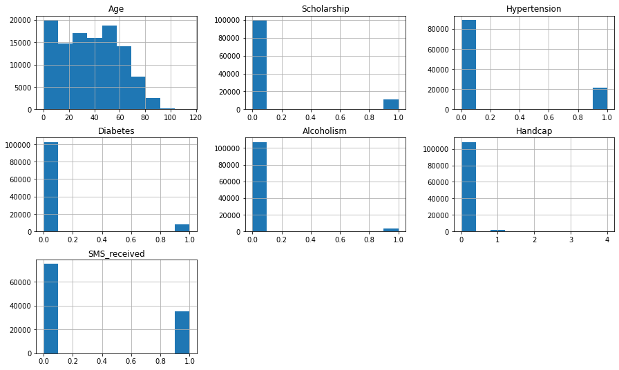

```python
# creating histgraph for whole dataset using hist ().
#using figsize to specify the size of graphs.
df.hist(figsize=(15,9));
```

The result of visulization the general over view indicate the following: 1-only about 9 % of total number of patients have Scholarship program and most of them have not Scholarship.

2-only fifth of patients (20% of total patients) suffering from hypertension,i.e count of patients without hypertension disease equal 4 times the patients who have hypertension disease, so most of patients not suffuring from Hypertension.

3-only about 7 % of total patients who suffering from Diabetes, so it is consider rare disease in the data set.

4- most of patients not suffering from chronic diseases, however the count of hypertension higher than Diabetes patients.

5-most of patients not Alcoholic addicts, the alcoholic addicts is very rare in the patients dada set.

6- the count of patients who recived an SMS equal the half of patients who did not recive an SMS, so the SMS program may need to revised to include most of patients.

7- only 10% of patients have a wellfare program (scholarship), most of them have not which could affect the attendance.

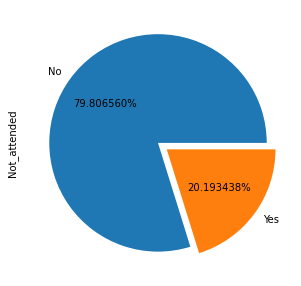

```python
#  data visualization for the count of attended patients and compare it with not attended pateints with ploting pie graph.

df.Not_attended.value_counts().plot.pie(figsize=(5,5),autopct='%2f%%',explode=(0,.1));
```

about 20 percent of total patients did not attended , i.e:the count of not attended patients equal the forth (1/4) of attended patients in their appointment days.

```python
#creating a new separated two datframes for collecting the attended and not attended patients pirior to analysis.
#comparing between the sum count of attended and not attended patients using count() and sum() functions.
Attended=(df.Not_attended =='No')
Not_attended=(df.Not_attended =='Yes')
df[Attended].count().sum(),df[Not_attended].count().sum()
```

```
(882070, 223190)
```

the output confirmed the above graph results that the count of patients who attend in thier appointments equal 4 times count of not attended patients.

```python
df[Attended].mean(),df[Not_attended].mean()
```

```
(Age             37.790504
 Scholarship      0.093904
 Hypertension     0.204394
 Diabetes         0.073838
 Alcoholism       0.030417
 Handcap          0.022742
 SMS_received     0.291337
 dtype: float64,
 Age             34.317667
 Scholarship      0.115507
 Hypertension     0.169004
 Diabetes         0.064071
 Alcoholism       0.030333
 Handcap          0.020297
 SMS_received     0.438371
 dtype: float64)
```

1-The average age of patients who atttended =37.7 years old , while the average age of not attended patients is 34.3 years old, which is almost similar so no clear relationship between age and attendance.

3- Mean for most of other paramaters is similar,which indicates no strong affect of them which will be investigated further.

### Research Question 2 : how the age could affect the attendance rate of patients?

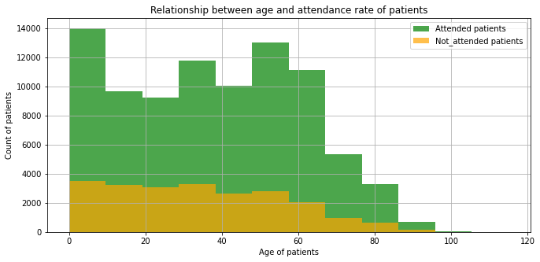

```python
#using matplotlip for visulization defenation of attendance rate.
# using the visualization plot for studing the affect of Age on the attendance rate and probability of attending.

import matplotlib.pyplot as plt


def attendance_rate(df,col_name,Attended,Not_attended):
    plt.figure(figsize=[11,5])
    df[col_name][Attended].hist(alpha=.7,bins=12,color="green",label="Attended patients")
    df[col_name][Not_attended].hist(alpha=.7,bins=12,color="orange",label="Not_attended patients")
    plt.legend();
    plt.title("Relationship between age and attendance rate of patients")
    plt.ylabel("Count of patients")
    plt.xlabel("Age of patients")
attendance_rate(df,"Age",Attended,Not_attended)
```

1-The histgraph show that the highest range of attended patients recorded for the childerens below 9 years,which reflect the care of babies by their families.

2-the second peak for the highest attendance were at age range from 47 to 57 years old.

### Research Question 3 :Is there a relationship between gender type and the attendance rate of patients?

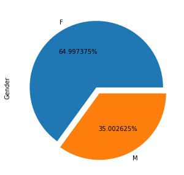

```python
# using Gender data fram for calculation the distrpution of males and females in the data set.
#using pie chart for visulization this process.
df.Gender.value_counts().plot.pie(figsize=(5,5),autopct='%2f%%',explode=(0,.1));
```

It is show that only 35% of patients were Males while the higher percent (65%) were from Females.

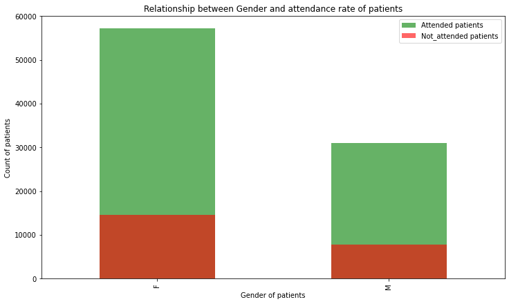

```python
#using the visualization plot bar graph for studing the affect of Gender on the attendance rate and probability of attending.

def attendance_rate(df,col_name,Attended,Not_attended):
    plt.figure(figsize=[12,7])
    df[col_name][Attended].value_counts().plot(kind='bar',alpha=.6,color="green",label="Attended patients")
    df[col_name][Not_attended].value_counts().plot(kind='bar',alpha=.6,color="red",label="Not_attended patients")
    plt.legend();
    plt.title("Relationship between Gender and attendance rate of patients")
    plt.ylabel("Count of patients")
    plt.xlabel("Gender of patients")
attendance_rate(df,"Gender",Attended,Not_attended)
```

1-The bar chart show that the patients count of Females are generaly higher than the males.

2- almost the forth of males and females did not attend in thier appointments.

3- no clear relationship between the type of gender of patient and the attendance rate.

### Research Question 4 : how does the age and gender as compined paramater could affect the attendance rate of patients?

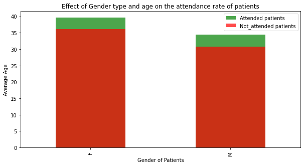

```python
# using the visualization plot bar graph for studing the affect of both Gender and age of patients on the attendance rate
# and probability of attending.

plt.figure(figsize=[10,5]) #using figsize for fixing the size of graph.
df[Attended].groupby(['Gender']).mean()['Age'].plot(kind='bar',alpha=.7,color="green",label="Attended patients");
df[Not_attended].groupby(['Gender']).mean()['Age'].plot(kind='bar',alpha=.7,color="red",label="Not_attended patients");
plt.legend();
plt.title("Effect of Gender type and age on the attendance rate of patients")
plt.ylabel("Average Age")
plt.xlabel("Gender of Patients")
```

1-the mean age of Females larger than for the Males.

2-the visulization chart demonstrate that the almost the identically for the percent of attended patients from Males and Females.

3- No clear affect of the gender on the attendance rate.

### Research Question 5 : how to study the effect of Diabetes and age of patients on the attendance rate of patients ?

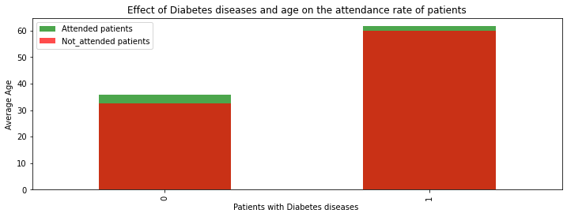

```python
# using the visualization plot bar graph for studing the affect of both diabetes and age of patients on the attendance rate
# and probability of attending.

plt.figure(figsize=[12,4]) #using figsize for fixing the size of graph.
df[Attended].groupby(['Diabetes']).mean()['Age'].plot(kind='bar',alpha=.7,color="green",label="Attended patients")
df[Not_attended].groupby(['Diabetes']).mean()['Age'].plot(kind='bar',alpha=.7,color="red",label="Not_attended patients")
plt.legend();
plt.title("Effect of Diabetes diseases and age on the attendance rate of patients")
plt.ylabel("Average Age")
plt.xlabel("Patients with Diabetes diseases ");
```

1-the mean age of patients with diabites(60 years) larger than for the patients without dibites(35 years).

2-the visulization chart demonstrate that the the percent of attended patients from free Diabetes larger than and patients whom suffering from Diabetes.

3- weak affect of the Diabetes on the attendance rate.

### Research Question 6 : how to study the effect of Alcoholism and age of patients on the attendance rate of patients ?

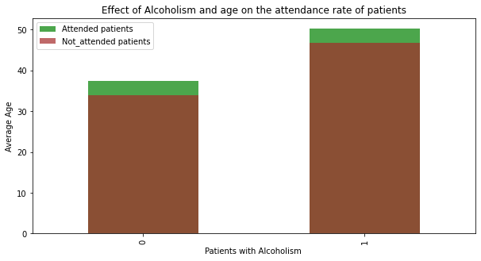

```python
plt.figure(figsize=[10,5]) #using figsize for fixing the size of graph.
df[Attended].groupby(['Alcoholism']).mean()['Age'].plot(kind='bar',alpha=.7,color="green",label="Attended patients")
df[Not_attended].groupby(['Alcoholism']).mean()['Age'].plot(kind='bar',alpha=.7,color="brown",label="Not_attended patients")
plt.legend();
plt.title("Effect of Alcoholism and age on the attendance rate of patients")
plt.ylabel("Average Age")
plt.xlabel("Patients with Alcoholism ");
```

1-the mean age of alcoholic addects is about 50 years while the mean age of non addects is about 36 years.

2-the percent of attended and non attended patients from alcoholic addects and non addects is similar.

3- no clear effect of the Alcoholism on the attendance rate.

### Research Question 7 : how to visualize the effect of hypertension and age of patients on the attendance rate of patients ?

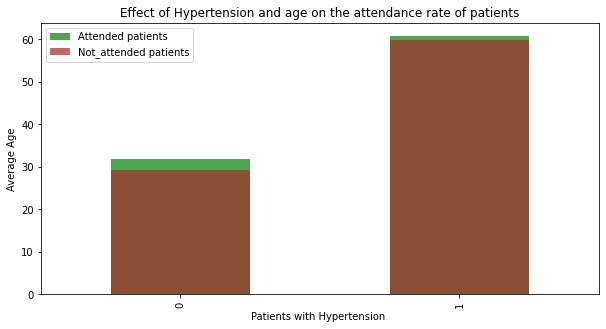

```python
plt.figure(figsize=[10,5]) #using figsize for fixing the size of graph.
df[Attended].groupby(['Hypertension']).mean()['Age'].plot(kind='bar',alpha=.7,color="green",label="Attended patients")
df[Not_attended].groupby(['Hypertension']).mean()['Age'].plot(kind='bar',alpha=.7,color="brown",label="Not_attended patients")
plt.legend();
plt.title("Effect of Hypertension and age on the attendance rate of patients")
plt.ylabel("Average Age")
plt.xlabel("Patients with Hypertension ");
```

```python
Not_attended=(df.Not_attended =='Yes')
Attended=(df.Not_attended =='No')
df[Not_attended].groupby(['Hypertension']).mean()['Age']
df[Attended].groupby(['Hypertension']).mean()['Age']
```

```
Hypertension
0    31.879193
1    60.800322
Name: Age, dtype: float64
```

1-the average age of patients with hypertension about 61 years while the average age for patients without hypertension 32 years.

2- No strong affect for the age and hypertension on the attendance rate.

### Research Question 8 : how does the Scholarship or welfare program of patients affect the attendance rate of patients in thier appointments?

```python
#using value_counts function to calculate the number of patients who have wellfare program and how have not.

df['Scholarship'].value_counts()
```

```
0    99665
1    10861
Name: Scholarship, dtype: int64
```

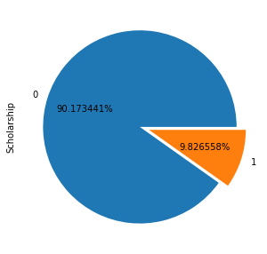

```python
# Using pie chart for visualization the percent of patient whom have a scholarship .

df.Scholarship.value_counts().plot.pie(figsize=(5,5),autopct='%2f%%',explode=(0,.1));
```

1-The output show that more than 90% of pateints have no welfare program which may signifcantly affect the attendance which will be further investigated.

2- small percent of patients have scholarship (9.8%).

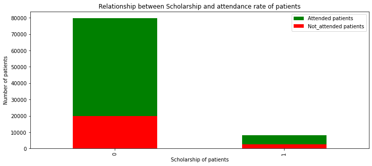

```python
#using the visualization plot bar graph for studing the affect of scholarship on the attendance rate
# and probability of attending.

def attendance_rate(df,col_name,Attended,Not_attended):
    plt.figure(figsize=[12,5])
    df[col_name][Attended].value_counts().plot(kind='bar',color="green",label="Attended patients")
    df[col_name][Not_attended].value_counts().plot(kind='bar',color="red",label="Not_attended patients")
    plt.legend();
    plt.title("Relationship between Scholarship and attendance rate of patients")
    plt.ylabel("Number of patients")
    plt.xlabel("Scholarship of patients")
attendance_rate(df,"Scholarship",Attended,Not_attended)
```

The above visualization process show that the Scholarship do not have a clear affect on the attendance rate of patients.

### Research Question 9 : what is the influence of Neighbourhood of patients on the attendance rate of patients in thier appointments?

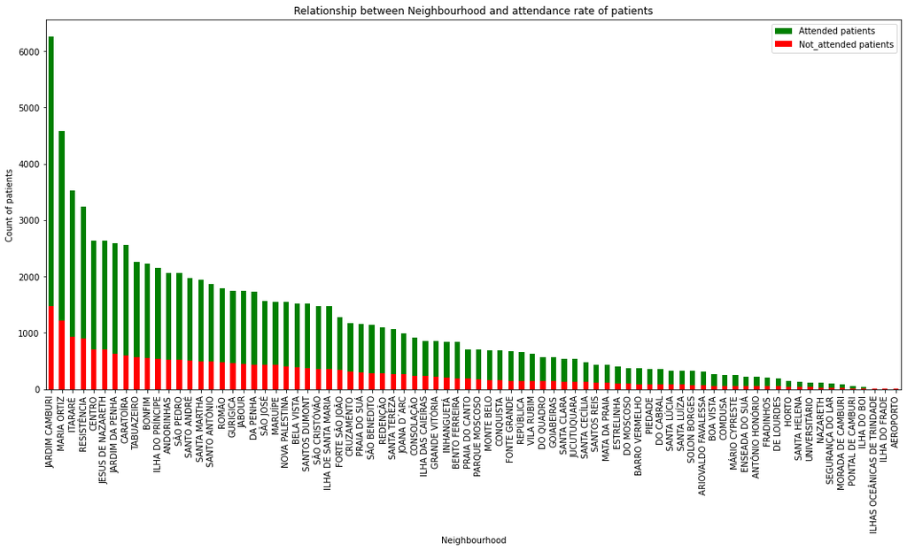

```python
plt.figure(figsize=[18,8])
df.Neighbourhood[Attended].value_counts().plot(kind='bar',color="green",label="Attended patients")
df.Neighbourhood[Not_attended].value_counts().plot(kind='bar',color="red",label="Not_attended patients")
plt.legend();
plt.title("Relationship between Neighbourhood and attendance rate of patients")
plt.ylabel("Count of patients")
plt.xlabel("Neighbourhood")
```

1-The visualization chart show that the highest count of attended patients recorded in JARDIM CAMBOURI, then started to decrease.

### Research Question 10 : how the reciving an SMS could affect the attendance rate of patients in thier appointments?

[figure not shown]

```python
def attendance_rate(df,col_name,Attended,Not_attended):
    plt.figure(figsize=[8,5])
    df[col_name][Attended].value_counts().plot(kind='bar',alpha=.6,color="green",label="Attended patients")
    df[col_name][Not_attended].value_counts().plot(kind='bar',alpha=.6,color="red",label="Not_attended patients")
    plt.legend();
    plt.title("Relationship between Gender and attendance rate of patients")
    plt.ylabel("Count of patients")
    plt.xlabel("SMS reciving for patients")
attendance_rate(df,"SMS_received",Attended,Not_attended)
```

```python
df[Not_attended].SMS_received.value_counts()
df[Attended].SMS_received.value_counts()
```

```
0    62509
1    25698
Name: SMS_received, dtype: int64
```

```python
df[Not_attended].SMS_received.value_counts()
```

```
0    12535
1     9784
Name: SMS_received, dtype: int64
```

1-The chart show that the patients whom did not recive an SMS equal the douple of patient whom recived an SMS.

2- The above equations confirm the unique issue that the count of patients whom attended without reciving an SMS larger than whom attend after reciving an SMS, so the SMS program to be revised .

### Research Question 11 : is any diferent effect of the SMS on the attendance rate of patients in various Neighbourhood ?

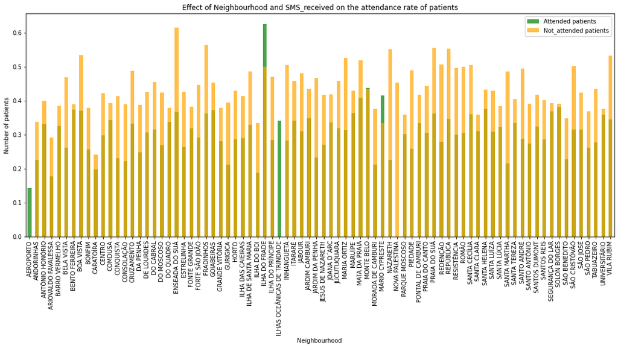

```python
plt.figure(figsize=[18,7]) #using figsize for fixing the size of graph.
df[Attended].groupby(['Neighbourhood']).mean()['SMS_received'].plot(kind='bar',alpha=.7,color="green",label="Attended patients")
df[Not_attended].groupby(['Neighbourhood']).mean()['SMS_received'].plot(kind='bar',alpha=.7,color="orange",label="Not_attended patients")
plt.legend();
plt.title("Effect of Neighbourhood and SMS_received on the attendance rate of patients")
plt.ylabel("Number of patients")
plt.xlabel("Neighbourhood ")
```

1- the chart show that the green color for the SMS effect apperaed in only five Neighbourhoods with various strenth.

2-two Neighbourhoods have a very strong effect for the SMS in these two Neighbourhood.

3- may be the SMS content and program is differ between the Neighbourhoods so the effect are significantly different.

## Conclusions

#### Findings of project:

> 3- SMS content and program is differ between the Neighbourhoods so the effect are significantly different which is very strong in some Neighbourhoods.

> 4- the percent of patients whom attend without SMS reciving higher than whom attend after reciving SMS, which indicate that the SMS program sholud be revised.

> 5- there is a weak effect of the Diabetes on the attendance rate.

#### Limitations during the project:

> The effect of Many paramaters were studdied in this project but no clear relationship was observed between the attendance rate of patients and Gender, diabites, hypertension, alcoholism, or scholarship.

```python
from subprocess import call
call(['python', '-m', 'nbconvert', 'Investigate_a_Dataset.ipynb'])
```

```
1
```